# Approximation von Sonnenwinkeln und Strahlungsdaten

Bachelorprojekt Gruber, Jürgens, Obelöer

Hendrik Obelöer

28 July 2019

Das Ziel ist es, die vorher fest eingelesenen Strahlungswerte und Sonnenstandswinkel durch Formeln zu ersetzen und anzunähern. Die Genauigkeit dieser Modelle soll in diesem Dokument dargestellt werden.

# Veränderungen

| Version | Kommentar | Datum |
| --- | --- | --- |
| 1.0 | erste Version | 24.07.19 |

Der erste Test wird für die allgemeine Sonnenstrahlung ausgeführt. Diese sollte zwischen ~1320 (Juli) und ~1410 (Januar) liegen.

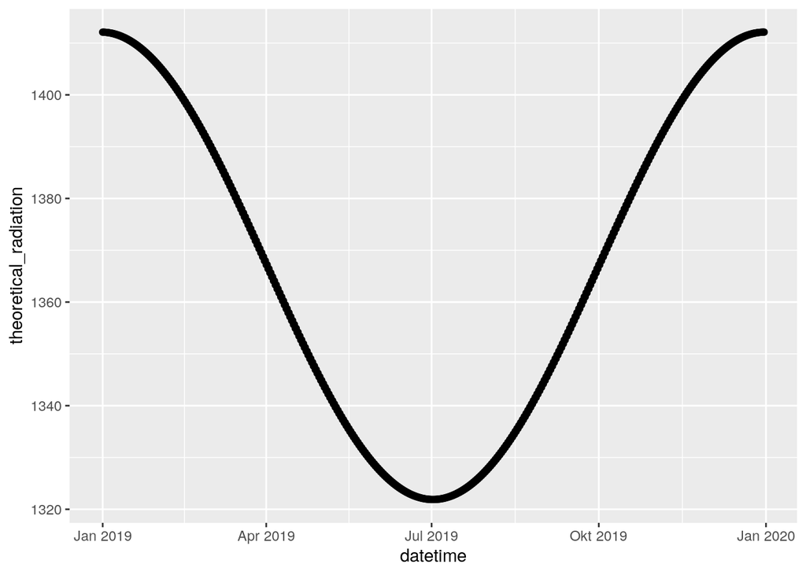

Als Grundlage für die erste Visualisierung dient der Karftreitag 2019. Dies war ein besonders wolkenloser Tag und war bereits in vorherigen Visualisierungen die Grundlage.

# Vergleich der Winkel

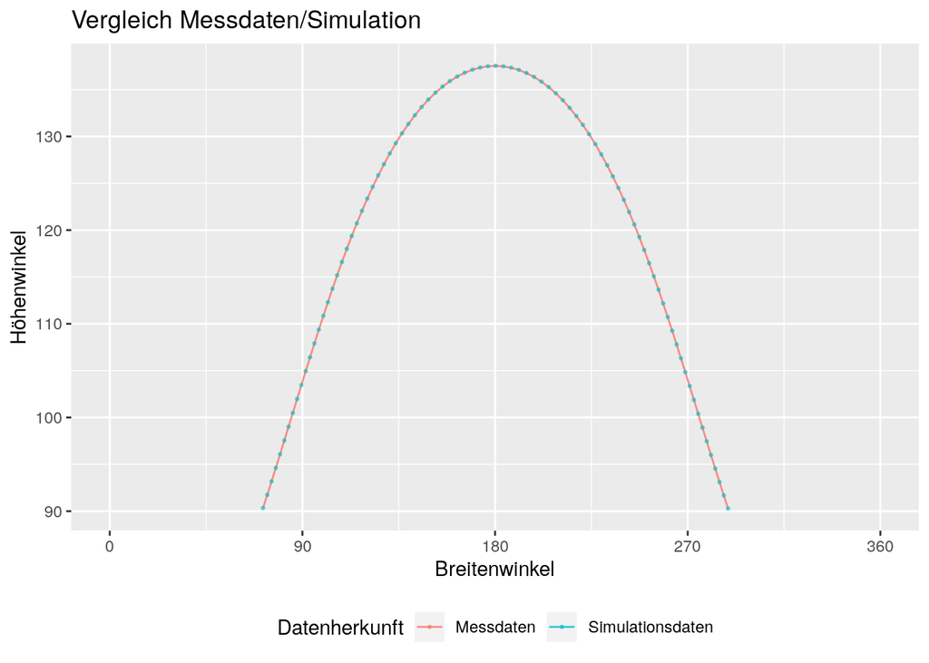

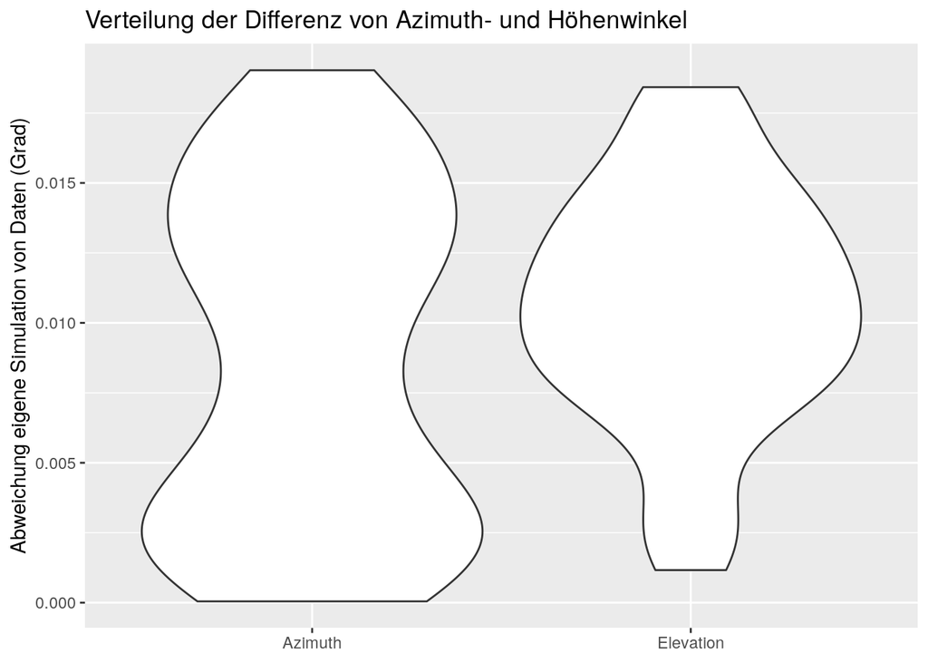

Die Winkel scheinen sich nahezu perfekt zu überlappen, dies bestätigt vorherige Stichproben. Abweichugen von bis zu 0,02 Grad pro Achse sollten keine maßgeblichen Einflüsse auf den nachher zu berechnenden Feststellwinkel haben.

# Vergleich der Strahlungsenergie

Als Einsieg wird wieder der Karfreitag ausgewählt, um die Simulation mit bekannten Daten zu vergleichen.

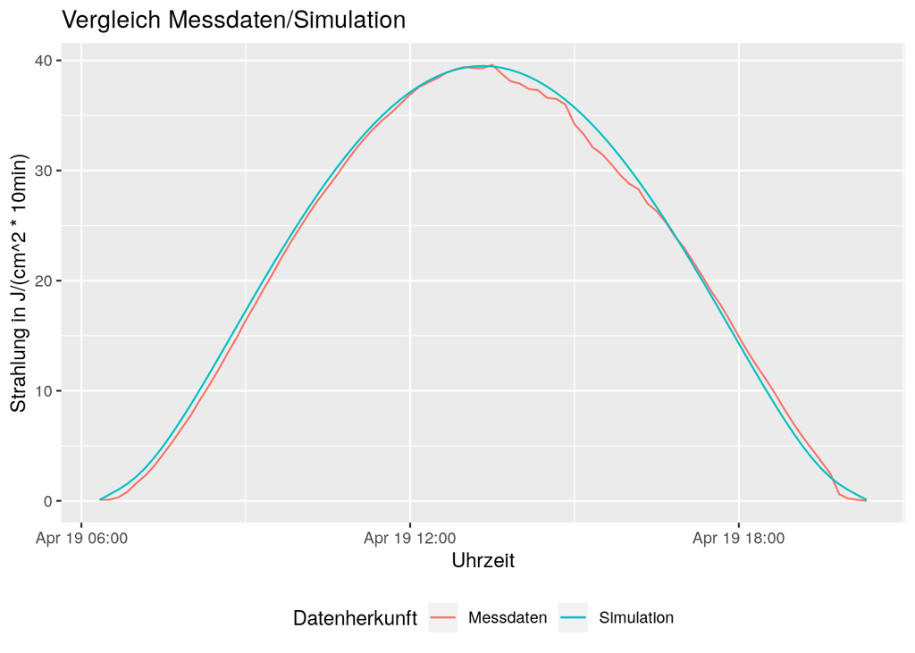

Die Form der simulierten Daten stimmen mit den tatsächlichen Messdaten überein. Es gibt eine Abweichung von wenigen Prozent.

Um auch zu vergleichen, wie das Modell mit Sommer/Winterwechsel umgeht wird der Vergleich für alle Monatsbeginne im Jahr 2018 wiederholt:

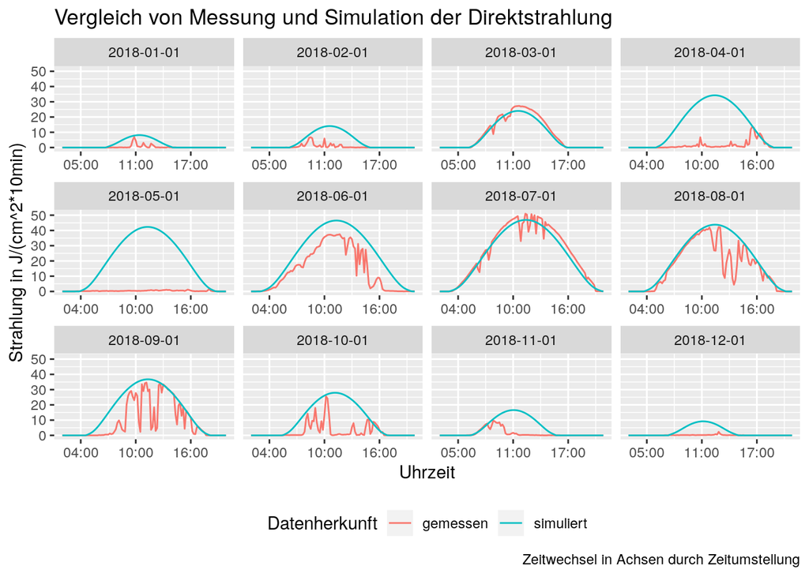

Bei den Messdaten ist zu beachten, dass Umwelteinflüsse natürlich die Werte in vielen Fällen stark vom idealen Modell abweichen lassen.

Dennoch scheint auch hier das Modell eine gute Grundlage für die weitere Rechnung zu liefern. Der absolute Wert des Modells ist dabei weniger wichtig als die Form der Kurve bzw. das Verhältnis der produzierten Daten zueinander. Dies scheint sehr gut die tatsächlichen Verhältnisse wiederzuspiegeln.